# LAB1

## Attributes: vertex attributes, edge attributes, graph attributes

use $ to create attributes and get attributes

```r
V(g4)$name # automatically generated when we created the network.
```

```
## [1] "John"     "Jim"      "Jack"     "Jesse"    "Janis"    "Jennifer"
## [7] "Justin"
```

```r
V(g4)$gender <- c("male", "male", "male", "male", "female", "female", "male")
neighbors(g4,"Jim",mode = "all")$gender
```

```
## [1] "male" "male" "male"
```

```r
E(g4)$type <- "email" # Edge attribute, assign "email" to all edges
E(g4)$weight <- 10    # Edge weight, setting all existing edges to 10
g4 <- set_graph_attr(g4, "name", "Email Network")
```

see the attributes

```r
edge_attr(g4)
```

```
## $type
## [1] "email" "email" "email" "email"
##
## $weight
## [1] 10 10 10 10
```

```r
vertex_attr(g4)
```

```
## $name
## [1] "John"     "Jim"      "Jack"     "Jesse"    "Janis"    "Jennifer"
## [7] "Justin"
##
## $gender
## [1] "male"   "male"   "male"   "male"   "female" "female" "male"
```

```r
graph_attr(g4)
```

```
## $name
## [1] "Email Network"
```

```r
graph_attr_names(g4)
```

```
## [1] "name"
```

```r
graph_attr(g4, "name")
```

```
## [1] "Email Network"
```

can remove the attribute

```r
g4 <- set_graph_attr(g4, "something", "A thing")
g4 <- delete_graph_attr(g4, "something")
graph_attr(g4)
```

```
## $name
## [1] "Email Network"
```

Make use of these attributes

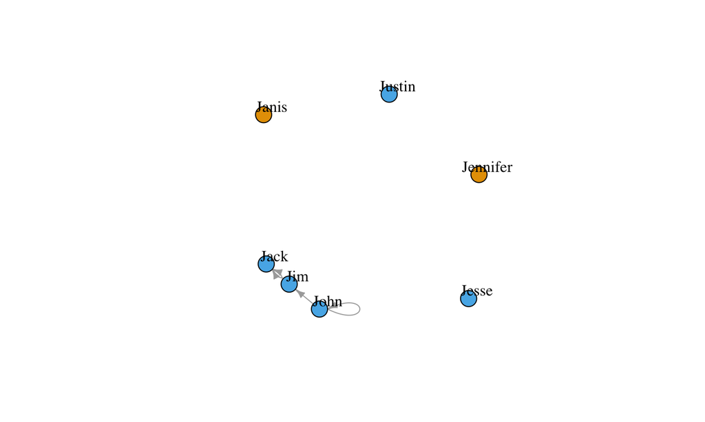

```r
plot(g4, edge.arrow.size=.5, vertex.label.color="black", vertex.label.dist=1.5,
     vertex.color=as.factor(V(g4)$gender) )
```

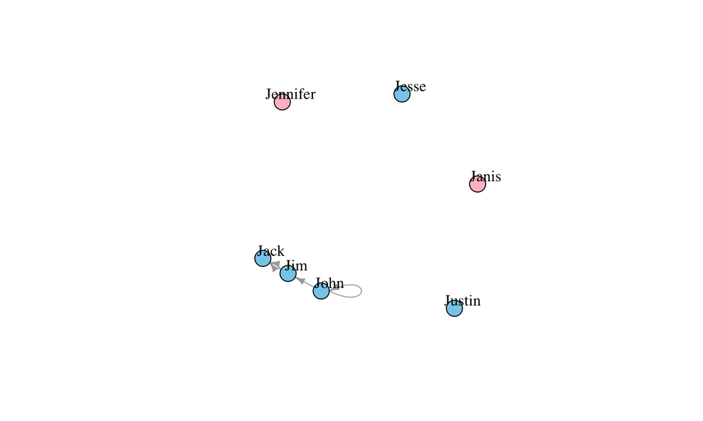

```r
plot(g4, edge.arrow.size=.5, vertex.label.color="black", vertex.label.dist=1.5,
     vertex.color=c( "pink", "skyblue")[1+(V(g4)$gender=="male")] )
```

```r
#consider as a sequence
```

attributes can be combined

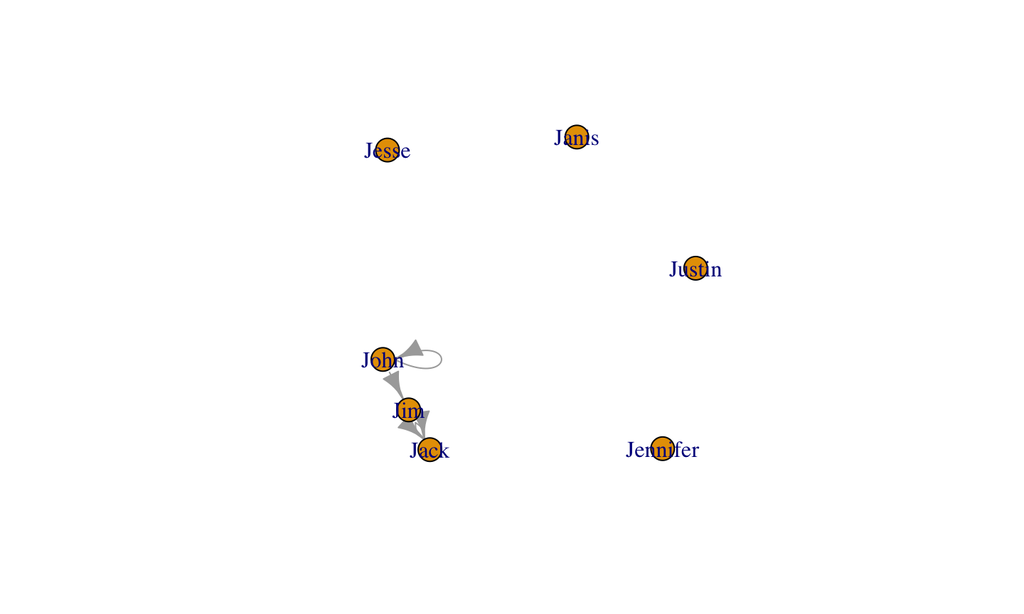

```r
plot(g4)
```

```r
g4s <- simplify( g4, remove.multiple = T, remove.loops = F,
                 edge.attr.comb=c(weight="sum", type="ignore") )
#specifies what to do with edge attributes, if remove.multiple=TRUE. In this case many edges might be mapped to a single one in the new graph, and their attributes are combined.
E(g4)$type
```

```
## [1] "email" "email" "email" "email"
```

```r
E(g4s)$type
```

[output not shown]

```r
E(g4)$weight
```

```
## [1] 10 10 10 10
```

```r
E(g4s)$weight
```

```
## [1] 10 10 20
```

## special attributes

make sure to avoid using these attribute names: color(e/v), layout(g), name(v),shape(v),type(v),weight(e)

## 5 Description of igraph object

```r
g4s
```

```
## IGRAPH 8dbe2fe DNW- 7 3 -- Email Network
## + attr: name (g/c), name (v/c), gender (v/c), weight (e/n)
## + edges from 8dbe2fe (vertex names):
## [1] John->John John->Jim  Jim ->Jack
```

```r
data(karate)
karate
```

```
## IGRAPH 4b458a1 UNW- 34 78 -- Zachary's karate club network
## + attr: name (g/c), Citation (g/c), Author (g/c), Faction (v/n),
## | name (v/c), label (v/c), color (v/n), weight (e/n)
## + edges from 4b458a1 (vertex names):
##  [1] Mr Hi  --Actor 2  Mr Hi  --Actor 3  Mr Hi  --Actor 4
##  [4] Mr Hi  --Actor 5  Mr Hi  --Actor 6  Mr Hi  --Actor 7
##  [7] Mr Hi  --Actor 8  Mr Hi  --Actor 9  Mr Hi  --Actor 11
## [10] Mr Hi  --Actor 12 Mr Hi  --Actor 13 Mr Hi  --Actor 14
## [13] Mr Hi  --Actor 18 Mr Hi  --Actor 20 Mr Hi  --Actor 22
## [16] Mr Hi  --Actor 32 Actor 2--Actor 3  Actor 2--Actor 4
## [19] Actor 2--Actor 8  Actor 2--Actor 14 Actor 2--Actor 18
## + ... omitted several edges
```

```r
data(macaque)
macaque
```

```
## IGRAPH f7130f3 DN-- 45 463 --
## + attr: Citation (g/c), Author (g/c), shape (v/c), name (v/c)
## + edges from f7130f3 (vertex names):
##  [1] V1 ->V2     V1 ->V3     V1 ->V3A    V1 ->V4     V1 ->V4t
##  [6] V1 ->MT     V1 ->PO     V1 ->PIP    V2 ->V1     V2 ->V3
## [11] V2 ->V3A    V2 ->V4     V2 ->V4t    V2 ->VOT    V2 ->VP
## [16] V2 ->MT     V2 ->MSTd/p V2 ->MSTl   V2 ->PO     V2 ->PIP
## [21] V2 ->VIP    V2 ->FST    V2 ->FEF    V3 ->V1     V3 ->V2
## [26] V3 ->V3A    V3 ->V4     V3 ->V4t    V3 ->MT     V3 ->MSTd/p
## [31] V3 ->PO     V3 ->LIP    V3 ->PIP    V3 ->VIP    V3 ->FST
## [36] V3 ->TF     V3 ->FEF    V3A->V1     V3A->V2     V3A->V3
## + ... omitted several edges
```

## 6. Network and node descriptions

- Density: `edge_density`
- reciprocity,transitivity,diameter,…
- Degree: `degree`
- centrality and centralization:
  - `centr_degree`
  - `closeness`, `centr_clo`
  - `eigen_centrality`, `centr_eigen`
  - `betweenness`, `edge_betweenness`, `centr_betw`

## Density

The proportion of present edges from all possible ties.

```r
edge_density(er, loops=F)
```

```
## [1] 0.02040404
```

```r
ecount(er)/(vcount(er)*(vcount(er)-1))*2 #for a undirected network
```

```
## [1] 0.02040404
```

## Node degrees

'degree' has a mode of 'in' for in-degree, 'out' for out-degree, and 'all' or 'total' for total degree.

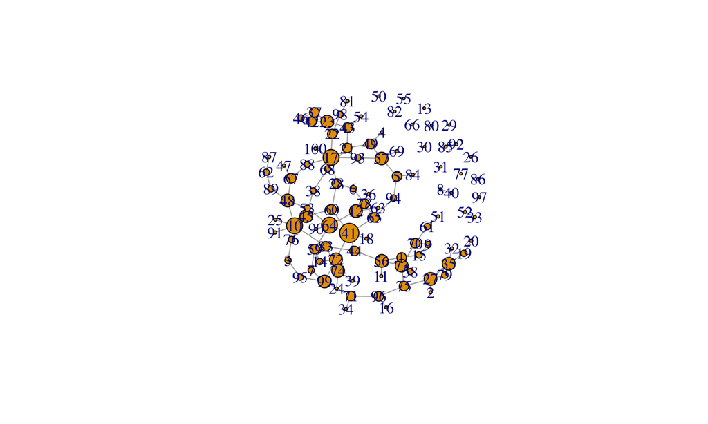

```r
deg <- degree(er, mode="all")
plot(er, vertex.size=deg*3)
```

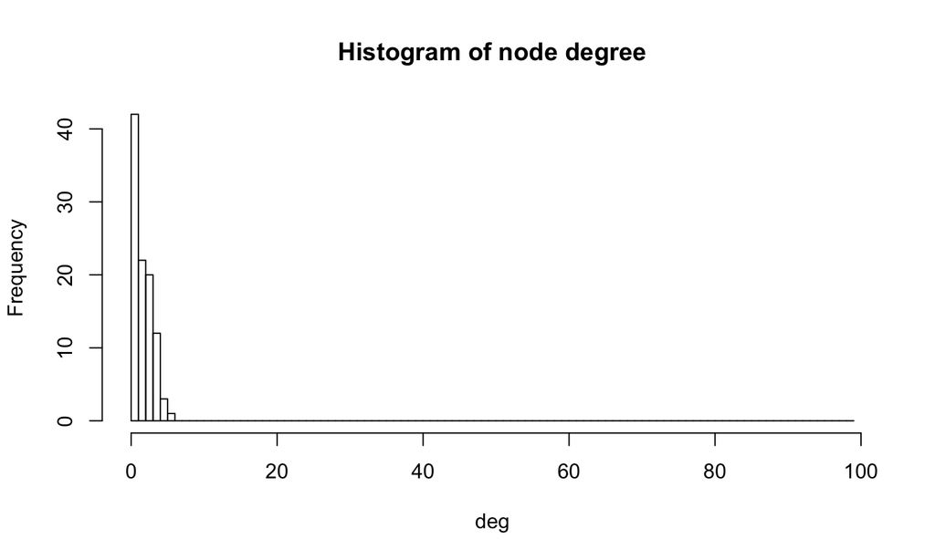

```r
hist(deg, breaks=1:vcount(er)-1, main="Histogram of node degree")
```

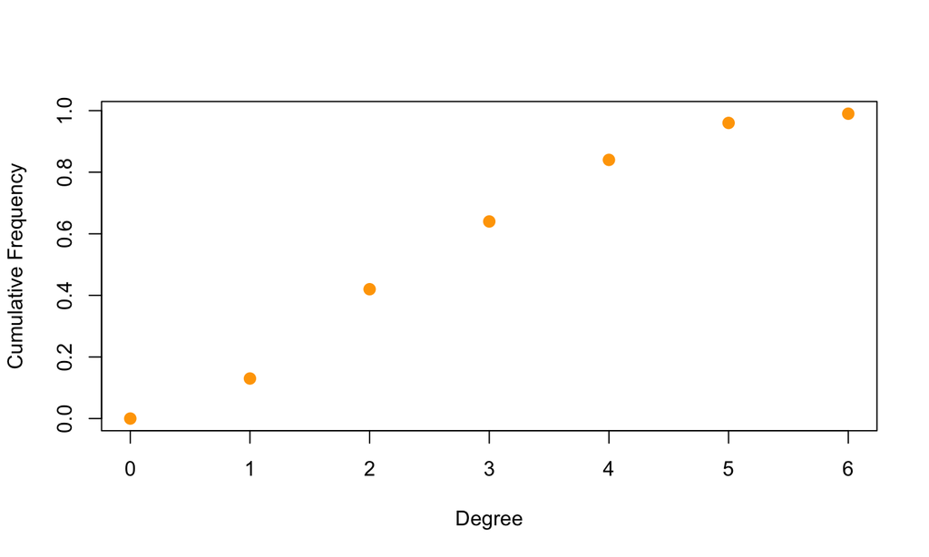

```r
deg.dist <- degree_distribution(er, cumulative=T, mode="all")
plot( x=0:max(deg), y=1-deg.dist, pch=19, cex=1.2, col="orange",
      xlab="Degree", ylab="Cumulative Frequency")
```

## centrality and centralization

Degree (number of ties)

```r
degree(er, mode="in")
```

```
##   [1] 3 1 2 1 3 2 2 1 2 5 1 4 0 2 2 1 5 1 2 1 3 3 4 1 1 0 4 3 0 0 0 1 1 1 4
##  [36] 1 3 2 1 1 6 3 3 3 4 2 1 4 3 0 1 1 2 1 0 4 4 2 3 3 2 2 1 5 3 0 3 2 1 3
##  [71] 3 4 4 4 3 2 0 3 2 0 1 0 3 1 1 0 1 2 2 1 1 1 2 2 2 3 0 2 4 1
```

```r
centr_degree(er, mode="in", normalized=T)
```

```
## $res
##   [1] 3 1 2 1 3 2 2 1 2 5 1 4 0 2 2 1 5 1 2 1 3 3 4 1 1 0 4 3 0 0 0 1 1 1 4
##  [36] 1 3 2 1 1 6 3 3 3 4 2 1 4 3 0 1 1 2 1 0 4 4 2 3 3 2 2 1 5 3 0 3 2 1 3
##  [71] 3 4 4 4 3 2 0 3 2 0 1 0 3 1 1 0 1 2 2 1 1 1 2 2 2 3 0 2 4 1
##
## $centralization
## [1] 0.04020202
##
## $theoretical_max
## [1] 9900
```

```r
###is there a mistake here?
##normalization should be
99*98
```

```
## [1] 9702
```

```r
## but it is
centr_degree(er, mode="in", normalized=T)$theoretical_max
```

```
## [1] 9900
```

Closeness (centrality based on distance to others in the graph) Inverse of the node's average geodesic distance to others in the network

```r
closeness(er, mode="all", weights=NA)
```

```
##   [1] 0.0004269855 0.0003998401 0.0004253509 0.0004025765 0.0004271679
##   [6] 0.0004312204 0.0004278990 0.0001020304 0.0004071661 0.0004422822
##  [11] 0.0004258944 0.0004344049 0.0001010101 0.0004325260 0.0004144219
##  [16] 0.0004084967 0.0004374453 0.0004376368 0.0003889537 0.0003773585
##  [21] 0.0004173623 0.0004264392 0.0004159734 0.0004231909 0.0004273504
##  [26] 0.0001010101 0.0004128819 0.0004426737 0.0001010101 0.0001010101
##  [31] 0.0001010101 0.0003886514 0.0001020304 0.0004152824 0.0004009623
##  [36] 0.0004199916 0.0004032258 0.0004319654 0.0004231909 0.0001020304
##  [41] 0.0004533092 0.0004032258 0.0004096682 0.0004484305 0.0004420866
##  [46] 0.0003909304 0.0004178855 0.0004387889 0.0004158004 0.0001010101
##  [51] 0.0003941663 0.0001020304 0.0004363002 0.0003968254 0.0001010101
##  [56] 0.0004407228 0.0004237288 0.0004192872 0.0004345937 0.0004490346
##  [61] 0.0004068348 0.0004113534 0.0004199916 0.0004440497 0.0004424779
##  [66] 0.0001010101 0.0004321521 0.0004239084 0.0004100041 0.0004199916
##  [71] 0.0004293688 0.0004448399 0.0004329004 0.0004378284 0.0004246285
##  [76] 0.0004315926 0.0001010101 0.0004357298 0.0004004806 0.0001010101
##  [81] 0.0003998401 0.0001010101 0.0004430660 0.0004132231 0.0001020304
##  [86] 0.0001010101 0.0003984064 0.0004280822 0.0004248088 0.0004290004
##  [91] 0.0004273504 0.0001020304 0.0004262575 0.0004332756 0.0004273504
##  [96] 0.0004221190 0.0001010101 0.0004128819 0.0004370629 0.0004228330
```

```r
centr_clo(er, mode="all", normalized=T)
```

```
## $res
##   [1] 0.04227156 0.03958417 0.04210974 0.03985507 0.04228962 0.04269082
##   [7] 0.04236200 0.01010101 0.04030945 0.04378594 0.04216354 0.04300608
##  [13] 0.01000000 0.04282007 0.04102777 0.04044118 0.04330709 0.04332604
##  [19] 0.03850642 0.03735849 0.04131886 0.04221748 0.04118136 0.04189590
##  [25] 0.04230769 0.01000000 0.04087531 0.04382470 0.01000000 0.01000000
##  [31] 0.01000000 0.03847649 0.01010101 0.04111296 0.03969527 0.04157917
##  [37] 0.03991935 0.04276458 0.04189590 0.01010101 0.04487761 0.03991935
##  [43] 0.04055715 0.04439462 0.04376658 0.03870211 0.04137066 0.04344011
##  [49] 0.04116424 0.01000000 0.03902247 0.01010101 0.04319372 0.03928571
##  [55] 0.01000000 0.04363156 0.04194915 0.04150943 0.04302477 0.04445442
##  [61] 0.04027665 0.04072398 0.04157917 0.04396092 0.04380531 0.01000000
##  [67] 0.04278306 0.04196694 0.04059041 0.04157917 0.04250751 0.04403915
##  [73] 0.04285714 0.04334501 0.04203822 0.04272767 0.01000000 0.04313725
##  [79] 0.03964758 0.01000000 0.03958417 0.01000000 0.04386354 0.04090909
##  [85] 0.01010101 0.01000000 0.03944223 0.04238014 0.04205607 0.04247104
##  [91] 0.04230769 0.01010101 0.04219949 0.04289428 0.04230769 0.04178978
##  [97] 0.01000000 0.04087531 0.04326923 0.04186047
##
## $centralization
## [1] 0.0184946
##
## $theoretical_max
## [1] 49.24873
```

Eigenvector (centrality proportional to the sum of connection centralities) Values of the first eigenvector of the graph adjacency matrix

```r
eigen_centrality(er, directed=T, weights=NA)
```

```
## $vector
##   [1] 1.371134e-01 1.648876e-02 9.025017e-02 1.137997e-02 8.171797e-02
##   [6] 1.884029e-01 2.423383e-01 8.661116e-17 4.011912e-02 4.331890e-01
##  [11] 9.010271e-02 4.102646e-01 6.074541e-17 3.309600e-01 5.502360e-02
##  [16] 2.735462e-02 1.869714e-01 3.104599e-01 1.059710e-02 3.289973e-03
##  [21] 3.883628e-02 8.624283e-02 6.118819e-02 1.301432e-01 1.344878e-01
##  [26] 6.074541e-17 5.311075e-02 2.763643e-01 6.074541e-17 6.074541e-17
##  [31] 6.074541e-17 9.575691e-03 1.002556e-16 4.929350e-02 3.084357e-02
##  [36] 1.273707e-01 3.824004e-02 1.353298e-01 1.301432e-01 8.777210e-17
##  [41] 1.000000e+00 3.824004e-02 3.436596e-02 5.342100e-01 3.818294e-01
##  [46] 2.374400e-02 4.442666e-02 3.140270e-01 3.665519e-02 6.074541e-17
##  [51] 7.914778e-03 7.214987e-17 3.260676e-01 1.066925e-02 6.074541e-17
##  [56] 2.902233e-01 6.785114e-02 9.639927e-02 4.065609e-01 5.148027e-01
##  [61] 2.549372e-02 3.749567e-02 1.273707e-01 7.362457e-01 4.658393e-01
##  [66] 6.074541e-17 1.430995e-01 5.407158e-02 2.106506e-02 7.420121e-02
##  [71] 1.587757e-01 6.594704e-01 1.733913e-01 4.191950e-01 9.767443e-02
##  [76] 1.465618e-01 6.074541e-17 3.304867e-01 2.606445e-02 6.074541e-17
##  [81] 9.199215e-03 6.074541e-17 4.304818e-01 2.537015e-02 8.613395e-17
##  [86] 6.074541e-17 1.164090e-02 1.024738e-01 1.091337e-01 2.285748e-01
##  [91] 1.344878e-01 6.085849e-17 7.911219e-02 1.699946e-01 1.441365e-01
##  [96] 8.811001e-02 6.074541e-17 2.963093e-02 3.740175e-01 5.804713e-02
##
## $value
## [1] 3.221028
##
## $options
## $options$bmat
## [1] "I"
##
## $options$n
## [1] 100
##
## $options$which
## [1] "LA"
##
## $options$nev
## [1] 1
##
## $options$tol
## [1] 0
```

[output cut: 30 more lines]

```
##
## $options$iter
## [1] 5
##
## $options$nconv
## [1] 1
##
## $options$numop
## [1] 60
##
## $options$numopb
## [1] 0
##
## $options$numreo
## [1] 37
```

```r
centr_eigen(er, directed=T, normalized=T)
```

```
## $vector
##   [1] 1.371134e-01 1.648876e-02 9.025017e-02 1.137997e-02 8.171797e-02
##   [6] 1.884029e-01 2.423383e-01 3.223605e-17 4.011912e-02 4.331890e-01
##  [11] 9.010271e-02 4.102646e-01 1.912884e-17 3.309600e-01 5.502360e-02
##  [16] 2.735462e-02 1.869714e-01 3.104599e-01 1.059710e-02 3.289973e-03
##  [21] 3.883628e-02 8.624283e-02 6.118819e-02 1.301432e-01 1.344878e-01
##  [26] 1.912884e-17 5.311075e-02 2.763643e-01 1.912884e-17 1.912884e-17
##  [31] 1.912884e-17 9.575691e-03 2.552543e-17 4.929350e-02 3.084357e-02
##  [36] 1.273707e-01 3.824004e-02 1.353298e-01 1.301432e-01 3.066022e-17
##  [41] 1.000000e+00 3.824004e-02 3.436596e-02 5.342100e-01 3.818294e-01
##  [46] 2.374400e-02 4.442666e-02 3.140270e-01 3.665519e-02 1.912884e-17
##  [51] 7.914778e-03 3.875815e-17 3.260676e-01 1.066925e-02 1.912884e-17
##  [56] 2.902233e-01 6.785114e-02 9.639927e-02 4.065609e-01 5.148027e-01
##  [61] 2.549372e-02 3.749567e-02 1.273707e-01 7.362457e-01 4.658393e-01
##  [66] 1.912884e-17 1.430995e-01 5.407158e-02 2.106506e-02 7.420121e-02
##  [71] 1.587757e-01 6.594704e-01 1.733913e-01 4.191950e-01 9.767443e-02
##  [76] 1.465618e-01 1.912884e-17 3.304867e-01 2.606445e-02 1.912884e-17
##  [81] 9.199215e-03 1.912884e-17 4.304818e-01 2.537015e-02 1.884389e-17
##  [86] 1.912884e-17 1.164090e-02 1.024738e-01 1.091337e-01 2.285748e-01
##  [91] 1.344878e-01 1.552082e-17 7.911219e-02 1.699946e-01 1.441365e-01
##  [96] 8.811001e-02 1.912884e-17 2.963093e-02 3.740175e-01 5.804713e-02
##
## $value
## [1] 3.221028
##
## $options
## $options$bmat
## [1] "I"
##
## $options$n
## [1] 100
##
## $options$which
## [1] "LA"
##
## $options$nev
## [1] 1
##
## $options$tol
## [1] 0
```

[output cut: 37 more lines]

```
## $options$numop
## [1] 60
##
## $options$numopb
## [1] 0
##
## $options$numreo
## [1] 37
##
##
## $centralization
## [1] 0.8797337
##
## $theoretical_max
## [1] 98
```

Betweenness (centrality based on a broker position connecting others) (Number of geodesics that pass through the node or the edge)

```r
betweenness(er, directed=T, weights=NA)
```

```
##   [1]  128.166667    0.000000   56.233333    0.000000  268.166667
##   [6]   65.083333   44.166667    0.000000    8.333333  493.416667
##  [11]    0.000000  174.916667    0.000000    4.500000   31.000000
##  [16]    0.000000  722.050000    0.000000   79.000000    0.000000
##  [21]  181.033333  458.216667  304.050000    0.000000    0.000000
##  [26]    0.000000  449.000000  585.466667    0.000000    0.000000
##  [31]    0.000000    0.000000    0.000000    0.000000  233.000000
##  [36]    0.000000   39.000000  221.200000    0.000000    0.000000
##  [41] 1266.933333   39.000000  135.583333  979.916667  421.866667
##  [46]    0.000000    0.000000  424.833333  130.750000    0.000000
##  [51]    0.000000    0.000000  128.583333    0.000000    0.000000
##  [56]  943.833333  259.083333   11.833333   75.133333  696.183333
##  [61]   79.000000   79.000000    0.000000  417.716667  375.333333
##  [66]    0.000000  203.083333  177.033333    0.000000  206.333333
##  [71]  288.000000  435.466667  766.500000  197.000000  584.000000
##  [76]   83.400000    0.000000  101.666667    0.000000    0.000000
##  [81]    0.000000    0.000000  386.083333    0.000000    0.000000
##  [86]    0.000000    0.000000  138.333333  156.000000    0.000000
##  [91]    0.000000    0.000000  103.416667  275.166667   64.900000
##  [96]  215.000000    0.000000   79.000000  385.033333    0.000000
```

```r
edge_betweenness(er, directed=T, weights=NA)
```

```
##   [1] 102.66667  39.33333  80.00000 507.71667 330.71667  80.00000  80.00000
##   [8] 114.41667 578.21667 158.00000 304.00000  80.00000  80.00000 117.00000
##  [15]   1.00000  80.00000 117.00000   1.00000 147.78333 123.38333 730.58333
##  [22] 237.91667 285.20000  40.00000  40.00000 298.50000  80.00000  97.41667
##  [29]   1.00000 161.41667  80.00000 190.83333  80.00000 971.00000 239.16667
##  [36] 164.08333  42.83333  78.30000  19.83333 558.30000 659.35000 254.71667
##  [43]  80.00000  80.00000 179.91667 347.63333 175.75000 132.13333 399.83333
##  [50]  80.00000 235.75000 196.86667 237.20000  80.00000  57.33333 158.00000
##  [57]  80.00000  69.16667 396.46667 725.83333  60.83333 277.33333  80.00000
##  [64]  80.00000 170.50000 518.00000 549.00000 100.90000 145.90000  95.75000
##  [71]  89.91667  97.66667  76.00000   4.00000 370.41667 338.25000 143.50000
##  [78]  80.00000  80.00000 186.25000 170.41667 234.00000 158.00000  80.00000
##  [85]  80.00000   1.00000 171.91667 114.91667 297.16667 333.16667  91.56667
##  [92]  80.00000 249.00000 181.00000 158.00000  80.00000  90.03333 327.00000
##  [99] 314.80000 118.23333  80.00000
```

```r
centr_betw(er, directed=T, normalized=T)
```

```
## $res
##   [1]  128.166667    0.000000   56.233333    0.000000  268.166667
##   [6]   65.083333   44.166667    0.000000    8.333333  493.416667
##  [11]    0.000000  174.916667    0.000000    4.500000   31.000000
##  [16]    0.000000  722.050000    0.000000   79.000000    0.000000
##  [21]  181.033333  458.216667  304.050000    0.000000    0.000000
##  [26]    0.000000  449.000000  585.466667    0.000000    0.000000
##  [31]    0.000000    0.000000    0.000000    0.000000  233.000000
##  [36]    0.000000   39.000000  221.200000    0.000000    0.000000
##  [41] 1266.933333   39.000000  135.583333  979.916667  421.866667
##  [46]    0.000000    0.000000  424.833333  130.750000    0.000000
##  [51]    0.000000    0.000000  128.583333    0.000000    0.000000
##  [56]  943.833333  259.083333   11.833333   75.133333  696.183333
##  [61]   79.000000   79.000000    0.000000  417.716667  375.333333
##  [66]    0.000000  203.083333  177.033333    0.000000  206.333333
##  [71]  288.000000  435.466667  766.500000  197.000000  584.000000
##  [76]   83.400000    0.000000  101.666667    0.000000    0.000000
##  [81]    0.000000    0.000000  386.083333    0.000000    0.000000
##  [86]    0.000000    0.000000  138.333333  156.000000    0.000000
##  [91]    0.000000    0.000000  103.416667  275.166667   64.900000
##  [96]  215.000000    0.000000   79.000000  385.033333    0.000000
##
## $centralization
## [1] 0.2307914
##
## $theoretical_max
## [1] 480249
```

## Exercise

Compute the degree, closeness, eigenvector, and betweenness centrality of the actors in the Zachary karate club network. Plot the network, sizing the nodes based on the different centrality types.